# Replication of Racial Progress as Threat to the Status Hierarchy: Implications for Perceptions of Anti-White Bias by Wilkins & Kaiser (2014, Psychological Science)

Ellen Reinhart (ereinhar@stanford.edu)

January 12, 2019

## Introduction

### Original Paper

[Wilkins, C. L., & Kaiser, C. R. (2014). Racial progress as threat to the status hierarchy: Implications for perceptions of anti-White bias. *Psychological Science, 25*(2). https://doi.org/10.1177/0956797613508412](https://github.com/ecreinhart/wilkins2014/tree/master/original_paper)

### Repository

[Wilkins & Kaiser (2014) study 2 replication](https://github.com/ecreinhart/wilkins2014)

### Online Survey

[Preview Qualtrics survey](https://stanforduniversity.ca1.qualtrics.com/jfe/preview/SV_eyvQlTXQhqikcND?Q_SurveyVersionID=current&Q_CHL=preview)

### OSF Pre-Registration

[Link to Pre-Registration](https://osf.io/p79wz/)

## Introduction

Wilkins and Kaiser (2014) tested the effect of minority racial progress on perceptions of anti-White bias among White participants. In study two, the authors manipulated minority racial progress and found that status-legitimizing beliefs (SLB) moderate the effect of minority racial progress on perceptions of anti-White discrimination. In particular, participants who strongly endorse SLB and were randomly assigned to read an article about minority racial progress cited significantly more anti-White bias than high-SLB participants in the control condition. The focus of the current project is to replicate the finding in which high-SLBs moderate the effect of minority racial progress on perceptions of anti-White discrimination.

## Methods

White participants will be recruited from Amazon Mechanical Turk and randomly assigned to one of two conditions: racial progress or control. In the racial progress condition, participants will read a news article about racial minorities in high-status positions. In the control condition, participants will read a news article about a low-ranked swim team winning a championship. After reading the article, participants will complete measures of racial progress, system-legitimizing beliefs, anti-White bias, and demographics. Wilkins posted the racial progress and control news articles on her personal website along with the exact wording and formatting of the measures used in the study (see research materials on [Wilkins’ website](https://sites.wustl.edu/spia/research-materials/) or in the [replication repository](https://github.com/ecreinhart/wilkins2014/tree/master/original_paper)), which will allow for a very close replication.

### Power Analysis

The paper cites the original effect size as b = 0.49. When converted, the effect size is d = 1.1289, f = .5645, and f^2 = 0.31866025. The regression model testing the interaction of SLB x condition has three predictors (condition, SLB, and condition x SLB). Setting alpha = .05 yields the following samples:

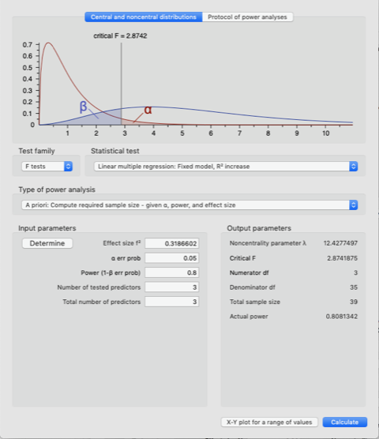

Gpower parameters for 80% power

80% power: 39  
90% power: 49  
95% power: 58

The large effect size allows a relatively small and feasible sample to have 80% power.

### Planned Sample

39 White Americans (above 18 years of age) were recruited using Turk Prime to target only White Mechanical Turk workers.

Exclusion criteria were set based on Dr. Wilkins’ instructions on exclusion criteria.

“We excluded data from people who failed attention checks. For example, we asked: ‘Verify that you are reading carefully by selecting strongly agree.’ - which was embedded in the SLB measures and ‘Do not select any response for this question’ embedded in anti-White bias measures.”"

### Materials

The materials described in the original paper or as described in detail on [Wilkins’ website](https://sites.wustl.edu/spia/research-materials/) were followed precisely unless otherwise noted.

As stated in the original paper, “All items were rated using scales from 1 (strongly disagree) to 7 (strongly agree).”

#### Manipulation

The replication used the exact wording of the two articles in the original with three exceptions. The publication date of each article was changed from 2009 to 2018. The date cited as the time by which race will no longer be a marker of social status in the U.S. (in the treatment condition article) was changed from 2020 to 2030. The date by which the swim team was said to compete in the Olympics (in the control condition article) was changed from 2012 to 2020.

Participants answered the same follow-up distractor questions as used in the original paper after reading the article. Find the follow-up questions on the original materials posted on [Wilkins’ website](https://sites.wustl.edu/spia/research-materials/).

#### Racial progress manipulation check

An item measuring participants’ agreement with the statement “Blacks in the U.S. are better off now (financially, politically, etc.) than they ever have been.”" served as the manipulation check.

#### Status-legitimizing beliefs

“Participants completed Levin, Sidanius, Rabinowitz, and Federico’s (1998) 12-item SLB measure, which assesses individuals’ beliefs regarding system legitimacy, or the perception that the system is fair (example item: “America is a just society where differences in status between ethnic groups reflect actual group differences”); system permeability, or the perception that all individuals, regardless of ethnicity, can achieve social advancement (example item: “America is an open society where individuals of any ethnicity can achieve higher status”); and Protestant work ethic, or the idea that hard work is rewarded (example item: “If people work hard they almost always get what they want”). We averaged these items and used the composite score in our analyses because the separate subscales functioned similarly across analyses (also see O’Brien & Major, 2005). Together, our SLB items assess the extent to which individuals believe that the system is fair and legitimate.”

#### Perceptions of anti-White bias

“We used eight items to assess perceptions of anti-White bias: (a) “Prejudice and discrimination against Whites are on the rise,” (b) “Whites are victims of racial bias,” (c) “Whites do not experience racism” (reverse-scored), (d) “Whites experience discrimination from Blacks,” (e) “Whites experience discrimination from other Whites,” (f) “Blacks and other racial groups benefit from preferential treatment that disadvantages Whites,” (g) “Reverse racism (where racial minorities are favored over Whites) is pervasive,” and (h) “Only racial minorities experience negative outcomes based on their race” (reverse-scored).”

### Procedure

The procedures described in the original articled were followed precisely. “Participants were told that they would be participating in two separate studies. The “first study” was described as an examination of reactions to news articles. Participants were randomly assigned to read one of two articles. In the racial-progress condition, participants read about high-status racial minorities in traditionally White positions (e.g., Barack Obama, Condoleezza Rice) and further read that social mobility is generalized to racial minorities in the United States (e.g., progress in college enrollment and income). In the control condition, participants read about an underdog swim team winning the national championship. This control article mirrored the racial-progress article in that it was about a low-status group becoming a higher-status group. Participants completed questions that tested their memory of the articles. The “second study” was described as an examination of perceptions of society. This portion of the procedure contained the measure of anti-White bias and a manipulation check.” “Participants then reported their endorsement of SLBs and demographic information.”

Demographic information will include gender, age, and race/ethnicity to check recruiting efforts of White participants.

### Analysis Plan

“Participants who randomly clicked through the survey were removed.”

“Mean-centered SLB scores and condition (0 = control, 1 = racial progress) were entered in Step 1 of a hierarchical linear regression. The two-way interaction between SLB and condition was entered in Step 2. In order to examine whether there were differences between conditions for individuals high and low in SLB endorsement, we tested the effects of condition for participants whose levels of SLB endorsement were high (1 SD above the centered mean) and low (1 SD below the centered mean; Cohen et al., 2003). Additionally, we examined simple slopes to determine whether SLB endorsement was related to anti-White bias within each condition.”

**The key analysis of interest is testing an interaction between status-legitimizing beliefs (SLB) and condition on perceptions of anti-White bias.**

To test whether the manipulation was effective, a t-test was also conducted for condition differences in perceptions of racial progress.

### Differences from Original Study

The sample, materials, and procedure exactly match the original study. One important difference is that the sociopolitical culture has changed since the original data was collected in 2009. Hate crimes rates in the United States have risen in recent years ([see BBC report on the increase](https://www.bbc.com/news/world-us-canada-41975573) and [FBI hate crime data](https://ucr.fbi.gov/hate-crime/2016)). I predict that increased racial tension in the United States will lead White American participants to feel more status threat, such that participants with high-SLB will cite more anti-White bias after reading about racial progress (i.e., the effect will be stronger).

#### Actual Sample

Final sample N=37 after 2 participants were excluded based on pre-set exclusion criteria.  
70% men, 30% women  
Mean age = 34 years, SD = 8.86  
62% Democrats, 27% Republicans, 11% Independents  
Mean score on 7-point political ideology scale = 3.35 (SD = 1.72), between “3 - Somewhat Liberal” and “4 - Moderate”

#### Differences from pre-data collection methods plan

None.

## Results

### Data preparation

Data preparation following the analysis plan.

```r
###Data Preparation

#load pacakges
library(tidyverse)
library(psych)
```

```r
library(ggthemes)
char = as.character
num = function(x) {return (as.numeric(char(x)))}
ci <- function(x) {sem(x) * 1.96} # reasonable approximation
sem <- function(x) {sd(x, na.rm=TRUE) / sqrt(sum(!is.na((x))))}

#import anonymized data from Qualtrics, numeric values
wilkins2014_raw <- read.csv("../data/wilkins & kaiser 2014 replication_December 5, 2018_13.06_anonymized.csv")

#remove first two rows that are headers and the first 31 rows (through row 33) which are previews
wilkins2014_formatted <- wilkins2014_raw[-(1:50),] %>%
  select(slb_1:slb_12,awb_1:awb_8,condition,rac_prog,race,attn_check_1,attn_check_2,separate,age,gender,pol_view,pol_party) #select variables of interest

#### Data exclusion / filtering

wilkins2014_formatted$gender = #rename codes for gender varible
  car::recode(wilkins2014_formatted$gender,"
              '1' = 'man';
              '2' = 'woman';
              '3' = 'non-binary';
              '4' = 'self-describe';
              '5' = 'other'")

wilkins2014_formatted$race = #rename codes for race varible
  car::recode(wilkins2014_formatted$race,"
              '1' = 'Asian/Asian American';
              '2' = 'Black/African American';
              '3' = 'Latino/Latina';
              '4' = 'Native American/Pacific Islander';
              '5' = 'White/European American';
              '6' = 'Other'")

wilkins2014_formatted$pol_party = #rename codes for political party varible
  car::recode(wilkins2014_formatted$pol_party,"
              '1' = 'Strong Democrat';
              '2' = 'Democrat';
              '3' = 'Leaning Democrat';
              '4' = 'Independent';
              '5' = 'Leaning Republican';
              '6' = 'Republican';
              '7' = 'Strong Republican'")

wilkins2014_formatted$pol_party_collapsed = #collapse political party into Dem, Rep, Ind
  car::recode(wilkins2014_formatted$pol_party,"
              'Strong Democrat' = 'Democrat';
              'Democrat' = 'Democrat';
              'Leaning Democrat' = 'Democrat';
              'Independent' = 'Independent';
              'Leaning Republican' = 'Republican';
              'Republican' = 'Republican';
              'Strong Republican' = 'Republican'")

#exclusions
wilkins2014_excluded <- wilkins2014_formatted %>%
  filter(race == "White/European American", #filter White participants only
         attn_check_1 == 7, #select if followed attn check instructing to select "7, strongly agree"
        attn_check_2 == "") %>% #select if followed attn check instructing to not select a value
  rowid_to_column("ID") %>% #add arbitrary participant ID
  mutate(age = num(age), #make demographic variables numeric
         pol_view = num(pol_view))

#tidy and change to numeric variables
wilkins2014_gathered = wilkins2014_excluded %>%
  select(ID,starts_with("slb_"),starts_with("awb_"),rac_prog,condition) %>% #select variables of interest
  gather("measurement", "value",
         -ID, -condition, -rac_prog) %>%
  mutate(value = num(value)) %>%
  separate (measurement,c("scale","item"), sep="_")
#reverse score anti-White bias (3, 8) and SLB (3, 4, 7, 8, 11, 12); composite each
wilkins2014_reverse_coded <- wilkins2014_gathered %>%
  mutate(value = ifelse(scale == "awb" & item %in% c(3, 8),
                        8- value,
                        value)) %>%
  mutate(value = ifelse(scale == "slb" & item %in% c(3, 4, 7, 8, 11, 12),
                        8- value,
                        value))

wilkins2014_composites = wilkins2014_reverse_coded %>%
  group_by(condition, ID, scale) %>%
  summarize(composite = mean(value)) %>%
  ungroup()

wilkins2014_spread = wilkins2014_composites %>%
  spread(scale,composite)

wilkins2014_centered = wilkins2014_spread %>%
  mutate(slb_centered = (scale(slb, center = TRUE, scale = FALSE)))
```

### Confirmatory analysis

The analyses as specified in the analysis plan.

“Mean-centered SLB scores and condition (0 = control, 1 = racial progress) were entered in Step 1 of a hierarchical linear regression. The two-way interaction between SLB and condition was entered in Step 2. In order to examine whether there were differences between conditions for individuals high and low in SLB endorsement, we tested the effects of condition for participants whose levels of SLB endorsement were high (1 SD above the centered mean) and low (1 SD below the centered mean; Cohen et al., 2003). Additionally, we examined simple slopes to determine whether SLB endorsement was related to anti-White bias within each condition.”

```r
#linear regression of condition*SLB interaction
model <- lm(awb ~ condition + slb_centered + condition*slb_centered, data=wilkins2014_centered)
summary(model)
```

```
##
## Call:
## lm(formula = awb ~ condition + slb_centered + condition * slb_centered,
##     data = wilkins2014_centered)
##
## Residuals:
##     Min      1Q  Median      3Q     Max
## -2.7188 -0.7993 -0.2005  0.6026  2.8638
##
## Coefficients:
##                                 Estimate Std. Error t value Pr(>|t|)
## (Intercept)                       3.6908     0.3222  11.456 7.38e-13 ***
## conditiontreatment                0.1525     0.4408   0.346   0.7317
## slb_centered                      0.8471     0.3157   2.683   0.0114 *
## conditiontreatment:slb_centered  -0.1474     0.3626  -0.406   0.6871
## ---
## Signif. codes:  0 '***' 0.001 '**' 0.01 '*' 0.05 '.' 0.1 ' ' 1
##
## Residual standard error: 1.296 on 32 degrees of freedom
##   (1 observation deleted due to missingness)
## Multiple R-squared:  0.4291, Adjusted R-squared:  0.3756
## F-statistic: 8.018 on 3 and 32 DF,  p-value: 0.0003996
```

```r
#calculate condition*SLB coefficient
model_coefs = summary(model)$coefficients
model_coefs["conditiontreatment:slb_centered", "t value"]
```

```
## [1] -0.4064726
```

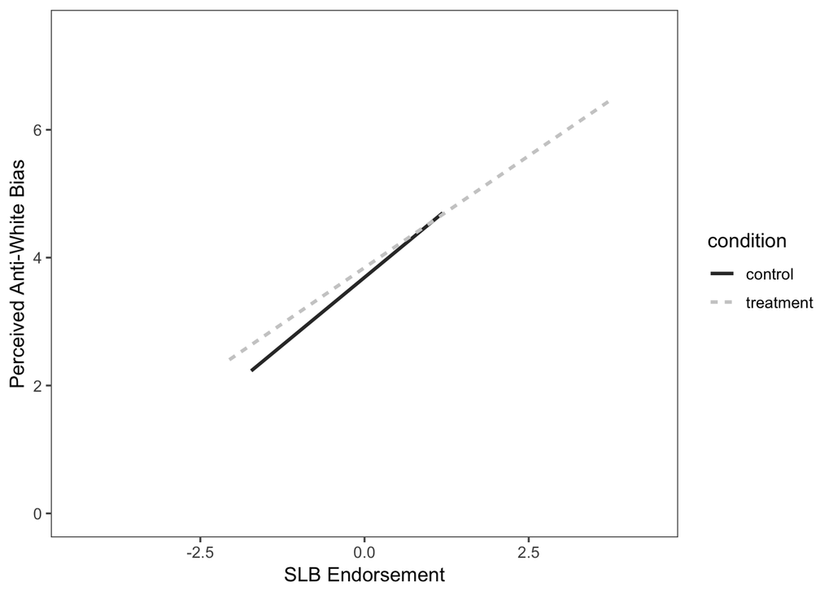

```r
#plot of condition*SLB interaction

most_extreme_x_value = 1.15*max(abs(wilkins2014_centered$slb_centered))

interaction_plot <- wilkins2014_centered %>%
  ggplot() +
  aes(x = slb_centered, y = awb, color = condition, linetype = condition) +
  xlim(-most_extreme_x_value,most_extreme_x_value) +
  ylim(0,7.5) +
  geom_smooth(method="lm", se=FALSE, na.rm=TRUE) +
  theme_few()+
  scale_color_grey()+
  xlab("SLB Endorsement")+
  ylab("Perceived Anti-White Bias")
interaction_plot
```

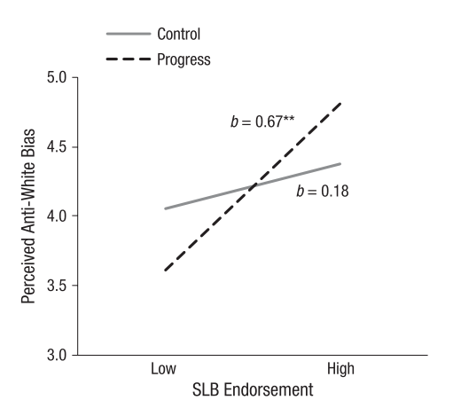

Figure 2 from Wilkins 2014 study 2 showing interaction between condition and SLB endorsement on perceived anti-White bias

```r
ggsave("../writeup/figures/interaction_plot.png", width=4, height=3)
```

```r
#sample demographics

#total after exclusions
nrow(wilkins2014_excluded)
```

```
## [1] 37
```

```r
#age
mean(wilkins2014_excluded$age)
```

```
## [1] 34.13514
```

```r
sd(wilkins2014_excluded$age)
```

```
## [1] 8.860531
```

```r
range(wilkins2014_excluded$age)
```

```
## [1] 22 57
```

```r
#gender
wilkins2014_excluded %>%
  group_by(gender) %>%
  summarize(count = n()) %>%
  mutate(percent_gender = count / nrow(wilkins2014_excluded) * 100)
```

```
## # A tibble: 2 x 3
##   gender count percent_gender
##   <fct>  <int>          <dbl>
## 1 man       26           70.3
## 2 woman     11           29.7
```

```r
#political ideology
mean(wilkins2014_excluded$pol_view)
```

```
## [1] 3.351351
```

```r
sd(wilkins2014_excluded$pol_view)
```

```
## [1] 1.719435
```

```r
#political party
wilkins2014_excluded %>%
  group_by(pol_party_collapsed) %>%
  summarize(count = n()) %>%
  mutate(percent_party = count / nrow(wilkins2014_excluded) * 100)
```

```
## # A tibble: 3 x 3
##   pol_party_collapsed count percent_party
##   <fct>               <int>         <dbl>
## 1 Democrat               23          62.2
## 2 Independent             4          10.8
## 3 Republican             10          27.0
```

### Exploratory analyses

```r
#prep data for manipulation of condition on racial progress
wilkins2014_manip_check <- wilkins2014_excluded %>%
  mutate(condition.n = ifelse(condition == "control",
                              0,
                              1)) %>%
   mutate(rac_prog = num(rac_prog))

#manipulation check of condition on racial progress
manip_check <- t.test(wilkins2014_manip_check$rac_prog ~ wilkins2014_manip_check$condition.n)
print(manip_check)
```

```
##
##  Welch Two Sample t-test
##
## data:  wilkins2014_manip_check$rac_prog by wilkins2014_manip_check$condition.n
## t = -3.2174, df = 30.119, p-value = 0.003088
## alternative hypothesis: true difference in means is not equal to 0
## 95 percent confidence interval:
##  -2.3085923 -0.5159691
## sample estimates:
## mean in group 0 mean in group 1
##        4.166667        5.578947
```

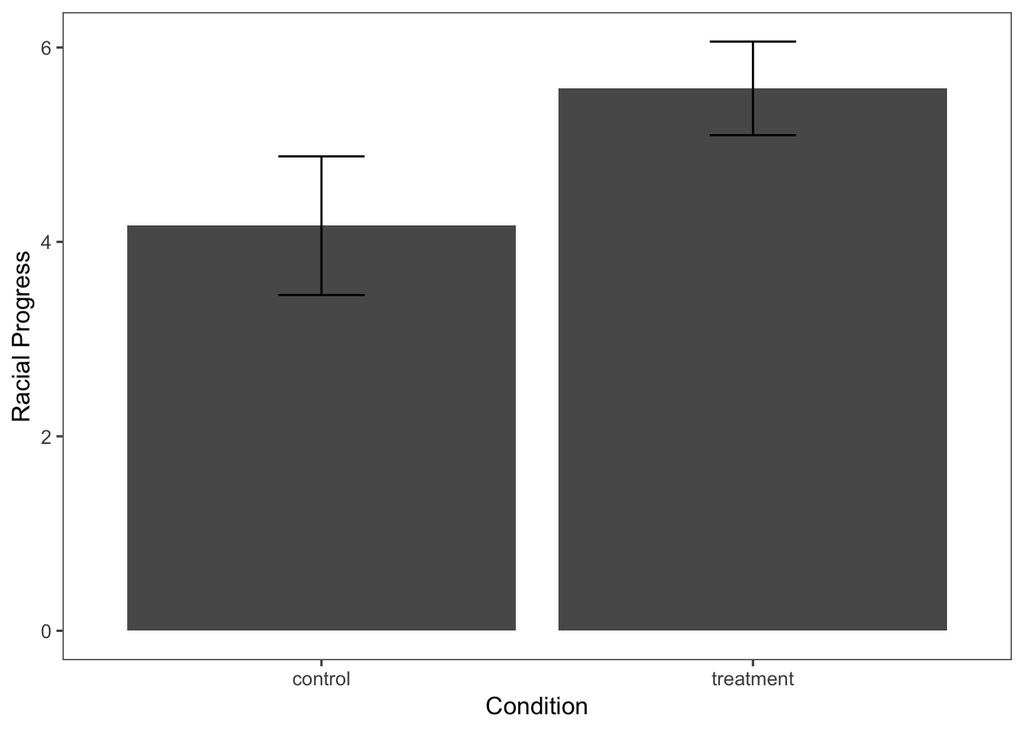

```r
#data prep for racial progress manipulation check plot
manip_check_plot_data <- wilkins2014_manip_check %>%
  select(ID,rac_prog,condition,rac_prog) %>%
  group_by(condition) %>%
  summarize(rac_prog_avg = mean(rac_prog),
            ci=ci(rac_prog),
            n=n())

#plot manipulation check
manp_check_plot <- manip_check_plot_data %>%
  ggplot(aes(x=condition, y=rac_prog_avg)) +
  geom_bar(position = "dodge", stat = "identity") +
  geom_errorbar(aes(ymin = rac_prog_avg - ci,
                    ymax = rac_prog_avg + ci),
                    width=.2,
                    position=position_dodge(.9)) +
  xlab("Condition") +
  ylab("Racial Progress") +
  theme_few()
manp_check_plot
```

```r
ggsave("../writeup/figures/manip_check_plot.png", width = 4, height = 3)
```

```r
#prep data for check on condition differences in believing separate studies
wilkins2014_separate_check <- wilkins2014_excluded %>%
  mutate(condition.n = ifelse(condition == "control",
                              0,
                              1)) %>%
   mutate(separate = num(separate))

#check on condition differences in believing separate studies
separate_check <- t.test(wilkins2014_separate_check$separate ~ wilkins2014_separate_check$condition.n)
print(separate_check)
```

```
##
##  Welch Two Sample t-test
##
## data:  wilkins2014_separate_check$separate by wilkins2014_separate_check$condition.n
## t = 5.2175, df = 34.173, p-value = 8.847e-06
## alternative hypothesis: true difference in means is not equal to 0
## 95 percent confidence interval:
##  1.776359 4.042354
## sample estimates:
## mean in group 0 mean in group 1
##        5.277778        2.368421
```

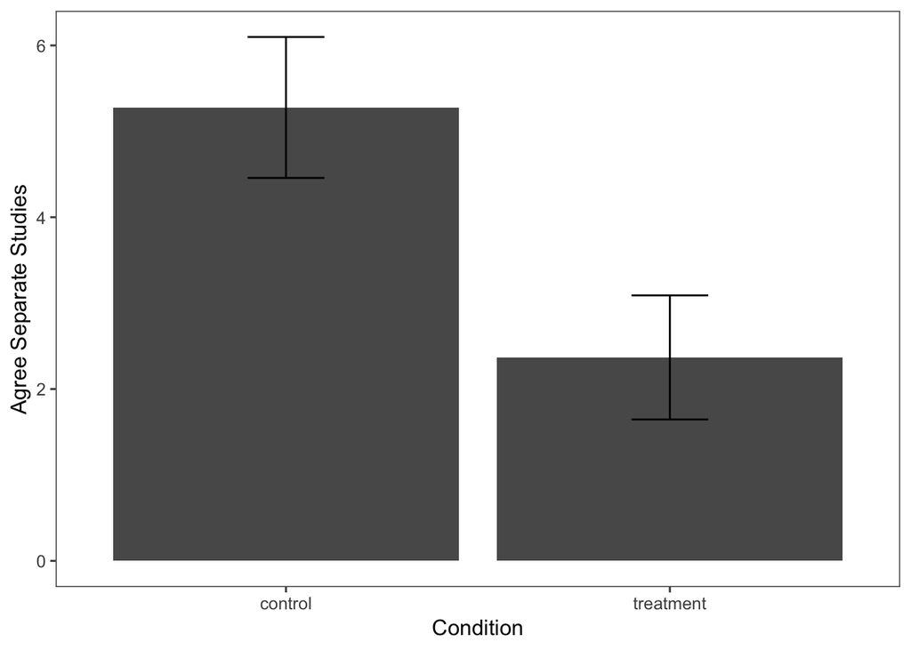

```r
#plot separate studies check
separate_check_plot_data <- wilkins2014_separate_check %>%
  select(ID,separate,condition,separate) %>%
  group_by(condition) %>%
  summarize(separate_avg = mean(separate),
            ci=ci(separate),
            n=n())

separate_check_plot <- separate_check_plot_data %>%
  ggplot(aes(x=condition, y=separate_avg)) +
  geom_bar(position = "dodge", stat = "identity") +
  geom_errorbar(aes(ymin = separate_avg - ci,
                    ymax = separate_avg + ci),
                    width=.2,
                    position=position_dodge(.9)) +
  xlab("Condition") +
  ylab("Agree Separate Studies") +
  theme_few()
separate_check_plot
```

```r
ggsave("../writeup/figures/separate_check_plot.png", width = 4, height = 3)
```

```r
#compare overall AWB scores to mean reported in original paper: "Perceptions of anti-White discrimination (alpha = .85; M = 4.21, SD = 1.12)"

AWB_mean = mean(wilkins2014_spread$awb, na.rm = TRUE)
AWB_sd = SD(wilkins2014_spread$awb, na.rm = TRUE)
print(AWB_mean)
```

```
## [1] 3.777778
```

```r
print(AWB_sd)
```

```
## [1] 1.639662
```

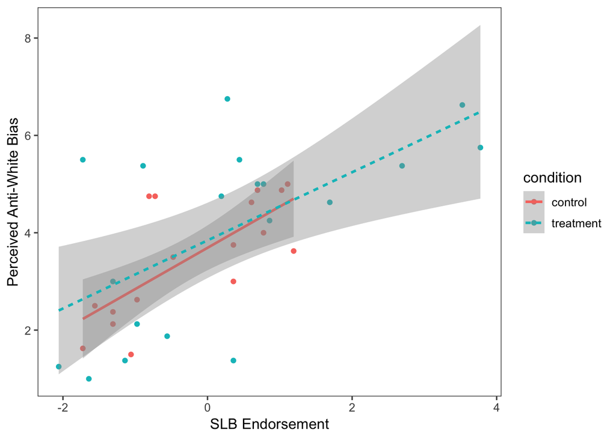

```r
#visualizing interaction scatter plot to see each data point

wilkins2014_centered %>%
ggplot() +
aes(x=slb_centered, y=awb, color=condition, linetype = condition) +
         geom_point(na.rm = TRUE) +
  geom_smooth(method=lm,
              se=TRUE,
              na.rm = TRUE) +
  xlab("SLB Endorsement") +
  ylab("Perceived Anti-White Bias") +
  theme_few()
```

## Discussion

### Summary of Replication Attempt

This project did not replicate the primary confirmatory analyses of the interaction between status-legitimizing beliefs (SLB) and racial progress (as manipulated by condition) on perceptions of anti-White bias (AWB). The analyses did replicate the significant main effect of SLB on AWB such that those high in SLB cited more AWB than those with low SLB. The manipulation of racial progress was successful, as participants in the racial progress condition agreed more with the racial progress manipulation check compared to participants in the control condition.

### Commentary

When planning the replication, the original author expressed concerns cohort effects such that manipulating racial progress may be more difficult in 2018 than it was in 2009 when the original data were collected. I was similarly concerned, but the results show that the racial progress manipulation was successful, as mentioned above.

Before running the study, our team was also concerned that participants might not believe the cover story that the two studies were not related to each other. At the end of the survey, a statement reiterated that participants were told the survey was on two separate studies. Then, we asked participants if they agreed that the studies were separate. Exploratory analyses showed that participants in the racial progress condition believed less than participants in the control condition that the two studies were separate. If participants in the racial progress condition thought the studies were related, they may have experienced self-presentation concerns and therefore cited less anti-White bias. This may account for why the racial progress manipulation checked showed condition differences but there was no interaction between SLB and condition. Given that asking if the studies were related could be open to interpretation, a more nuanced assessment of whether participants’ suspicion (e.g., progressive funnel debrief) would be helpful.

The replication had more Democrats than Republicans, which could have dampened the effect of racial progress and SLB on AWB. The original paper doesn’t report the political ideology or party of the sample.

Given the changes in America over the last nine years, including a new President, there could be other cohort effects that our data don’t speak to.

It’s also possible that the original paper over-estimated the effect size of the interaction. If that were the case, this sample would not be adequately powered to detect the interaction between SLB and racial progress on AWB. To test this hypothesis, one could run the same paradigm with a much larger sample to determine if the interaction is significant.